# Case Study On Cyclistic Bike Share

Diane KENGNE

2022-11-29

## Introduction

You are a junior data analyst working in the marketing analyst team at Cyclistic, a bike-share company in Chicago. The director of marketing believes the company’s future success depends on maximizing the number of annual memberships. Therefore, your team wants to understand how casual riders and annual members use Cyclistic bikes differently. From these insights, your team will design a new marketing strategy to convert casual riders into annual members. But first, Cyclistic executives must approve your recommendations, so they must be backed up with compelling data insights and professional data visualizations

### Goal

Design marketing strategies aimed at converting casual riders into annual members. In order to do that, however, the marketing analyst team needs to better understand how annual members and casual riders differ, why casual riders would buy a membership, and how digital media could affect their marketing tactics. Moreno and her team are interested in analyzing the Cyclistic historical bike trip data to identify trends.

Moreno is The director of marketing and your manager and is responsible for the development of campaigns and initiatives to promote the bike-share program

I will produce a report with the following deliverables: 1. A clear statement of the business task 2. A description of all data sources used 3. Documentation of any cleaning or manipulation of data 4. A summary of your analysis 5. Supporting visualizations and key findings 6. Your top three recommendations based on your analysis

### Business Task

Maximize the number of annual members by converting casual riders to members.

## Preparing, cleaning and manipulation of data

install packages

```r
install.packages("tidyverse", repos = "http://cran.us.r-project.org")
```

```r
install.packages("ggplot2", repos = "http://cran.us.r-project.org")
install.packages("janitor", repos = "http://cran.us.r-project.org")
install.packages("dplyr" , repos = "http://cran.us.r-project.org")
install.packages("skimr", repos = "http://cran.us.r-project.org")
install.packages("readr", repos = "http://cran.us.r-project.org")
```

Load packages

```r
library(tidyverse)
library(skimr)
library(janitor)
```

```r
library(readr)
library(ggplot2)
library(dplyr)
library(lubridate)
```

Import, read and rename .csv.files

```r
jan_2021 <- read_csv("202101-divvy-tripdata.csv")
fev_2021 <- read_csv("202102-divvy-tripdata.csv")
mar_2021 <- read_csv("202103-divvy-tripdata.csv")
apr_2021 <- read_csv("202104-divvy-tripdata.csv")
may_2021 <- read_csv("202105-divvy-tripdata.csv")
jun_2021 <- read_csv("202106-divvy-tripdata.csv")
jul_2021 <- read_csv("202107-divvy-tripdata.csv")
aug_2021 <- read_csv("202108-divvy-tripdata.csv")
sept_2021 <- read_csv("202109-divvy-tripdata.csv")
oct_2021 <- read_csv("202110-divvy-tripdata.csv")
nov_2021 <- read_csv("202111-divvy-tripdata.csv")
dec_2021 <- read_csv("202112-divvy-tripdata.csv")
```

Checking datasets for consistency

```r
head(jan_2021)
```

```
## # A tibble: 6 × 15
##   ride_id        ridea…¹ start…² ended…³ start…⁴ start…⁵ end_s…⁶ end_s…⁷ start…⁸
##   <chr>          <chr>   <chr>   <chr>   <chr>   <chr>   <chr>   <chr>     <dbl>
## 1 E19E6F1B8D4C4… electr… 2021-0… 2021-0… Califo… 17660   <NA>    <NA>       41.9
## 2 DC88F20C2C55F… electr… 2021-0… 2021-0… Califo… 17660   <NA>    <NA>       41.9
## 3 EC45C94683FE3… electr… 2021-0… 2021-0… Califo… 17660   <NA>    <NA>       41.9
## 4 4FA453A75AE37… electr… 2021-0… 2021-0… Califo… 17660   <NA>    <NA>       41.9
## 5 BE5E8EB4E7263… electr… 2021-0… 2021-0… Califo… 17660   <NA>    <NA>       41.9
## 6 5D8969F88C773… electr… 2021-0… 2021-0… Califo… 17660   <NA>    <NA>       41.9
## # … with 6 more variables: start_lng <dbl>, end_lat <dbl>, end_lng <dbl>,
## #   member_casual <chr>, ride_length <time>, day_of_week <dbl>, and abbreviated
## #   variable names ¹rideable_type, ²started_at, ³ended_at, ⁴start_station_name,
## #   ⁵start_station_id, ⁶end_station_name, ⁷end_station_id, ⁸start_lat
```

```r
head(fev_2021)
```

```
## # A tibble: 6 × 15
##   ride_id        ridea…¹ start…² ended…³ start…⁴ start…⁵ end_s…⁶ end_s…⁷ start…⁸
##   <chr>          <chr>   <chr>   <chr>   <chr>   <chr>   <chr>   <chr>     <dbl>
## 1 89E7AA6C29227… classi… 2021-0… 2021-0… Glenwo… 525     Sherid… 660        42.0
## 2 0FEFDE2603568… classi… 2021-0… 2021-0… Glenwo… 525     Boswor… 16806      42.0
## 3 E6159D746B2DB… electr… 2021-0… 2021-0… Clark … KA1503… State … TA1305…    41.9
## 4 B32D3199F1C2E… classi… 2021-0… 2021-0… Wood S… 637     Honore… TA1305…    41.9
## 5 83E463F23575F… electr… 2021-0… 2021-0… State … 13216   Emeral… TA1309…    41.8
## 6 BDAA7E3494E8D… electr… 2021-0… 2021-0… Fairba… 18003   LaSall… KP1705…    41.9
## # … with 6 more variables: start_lng <dbl>, end_lat <dbl>, end_lng <dbl>,
## #   member_casual <chr>, ride_length <time>, day_of_week <dbl>, and abbreviated
## #   variable names ¹rideable_type, ²started_at, ³ended_at, ⁴start_station_name,
## #   ⁵start_station_id, ⁶end_station_name, ⁷end_station_id, ⁸start_lat
```

```r
head(mar_2021)
```

```
## # A tibble: 6 × 15
##   ride_id        ridea…¹ start…² ended…³ start…⁴ start…⁵ end_s…⁶ end_s…⁷ start…⁸
##   <chr>          <chr>   <chr>   <chr>   <chr>   <chr>   <chr>   <chr>     <dbl>
## 1 CFA86D4455AA1… classi… 2021-0… 2021-0… Humbol… 15651   Stave … 13266      41.9
## 2 30D9DC61227D1… classi… 2021-0… 2021-0… Humbol… 15651   Centra… 18017      41.9
## 3 846D87A15682A… classi… 2021-0… 2021-0… Shield… 15443   Halste… TA1308…    41.8
## 4 994D05AA75A16… classi… 2021-0… 2021-0… Winthr… TA1308… Broadw… 13323      42.0
## 5 DF7464FBE92D8… classi… 2021-0… 2021-0… Glenwo… 525     Chicag… E008       42.0
## 6 CEBA8516FD17F… classi… 2021-0… 2021-0… Glenwo… 525     Chicag… E008       42.0
## # … with 6 more variables: start_lng <dbl>, end_lat <dbl>, end_lng <dbl>,
## #   member_casual <chr>, ride_length <time>, day_of_week <dbl>, and abbreviated
## #   variable names ¹rideable_type, ²started_at, ³ended_at, ⁴start_station_name,
## #   ⁵start_station_id, ⁶end_station_name, ⁷end_station_id, ⁸start_lat
```

```r
head(apr_2021)
```

```
## # A tibble: 6 × 15
##   ride_id        ridea…¹ start…² ended…³ start…⁴ start…⁵ end_s…⁶ end_s…⁷ start…⁸
##   <chr>          <chr>   <chr>   <chr>   <chr>   <chr>   <chr>   <chr>     <dbl>
## 1 6C992BD37A98A… classi… 2021-0… 2021-0… State … TA1307… Southp… 13235      41.9
## 2 1E0145613A209… docked… 2021-0… 2021-0… Dorche… KA1503… Dorche… KA1503…    41.8
## 3 E498E15508A80… docked… 2021-0… 2021-0… Loomis… 20121   Loomis… 20121      41.7
## 4 1887262AD101C… classi… 2021-0… 2021-0… Honore… TA1305… Southp… 13235      41.9
## 5 C123548CAB2A3… docked… 2021-0… 2021-0… Loomis… 20121   Loomis… 20121      41.7
## 6 097E76F3651B1… classi… 2021-0… 2021-0… Clinto… 15542   Clinto… 15542      41.9
## # … with 6 more variables: start_lng <dbl>, end_lat <dbl>, end_lng <dbl>,
## #   member_casual <chr>, ride_length <time>, day_of_week <dbl>, and abbreviated
## #   variable names ¹rideable_type, ²started_at, ³ended_at, ⁴start_station_name,
## #   ⁵start_station_id, ⁶end_station_name, ⁷end_station_id, ⁸start_lat
```

```r
head(may_2021)
```

```
## # A tibble: 6 × 15
##   ride_id        ridea…¹ start…² ended…³ start…⁴ start…⁵ end_s…⁶ end_s…⁷ start…⁸
##   <chr>          <chr>   <chr>   <chr>   <chr>   <chr>   <chr>   <chr>     <dbl>
## 1 C809ED75D6160… electr… 2021-0… 2021-0… <NA>    <NA>    <NA>    <NA>       41.9
## 2 DD59FDCE0ACAC… electr… 2021-0… 2021-0… <NA>    <NA>    <NA>    <NA>       41.9
## 3 0AB83CB88C43E… electr… 2021-0… 2021-0… <NA>    <NA>    <NA>    <NA>       41.9
## 4 7881AC6D39110… electr… 2021-0… 2021-0… <NA>    <NA>    <NA>    <NA>       41.9
## 5 853FA701B4582… electr… 2021-0… 2021-0… <NA>    <NA>    <NA>    <NA>       41.9
## 6 F5E63DFD96B2A… electr… 2021-0… 2021-0… <NA>    <NA>    <NA>    <NA>       41.9
## # … with 6 more variables: start_lng <dbl>, end_lat <dbl>, end_lng <dbl>,
## #   member_casual <chr>, ride_length <time>, day_of_week <dbl>, and abbreviated
## #   variable names ¹rideable_type, ²started_at, ³ended_at, ⁴start_station_name,
## #   ⁵start_station_id, ⁶end_station_name, ⁷end_station_id, ⁸start_lat
```

```r
head(jun_2021)
```

```
## # A tibble: 6 × 15
##   ride_id        ridea…¹ start…² ended…³ start…⁴ start…⁵ end_s…⁶ end_s…⁷ start…⁸
##   <chr>          <chr>   <chr>   <chr>   <chr>   <chr>   <chr>   <chr>     <dbl>
## 1 99FEC93BA843F… electr… 2021-0… 2021-0… <NA>    <NA>    <NA>    <NA>       41.8
## 2 06048DCFC8520… electr… 2021-0… 2021-0… <NA>    <NA>    <NA>    <NA>       41.8
## 3 9598066F68045… electr… 2021-0… 2021-0… <NA>    <NA>    <NA>    <NA>       41.8
## 4 B03C0FE48C412… electr… 2021-0… 2021-0… <NA>    <NA>    <NA>    <NA>       41.8
## 5 B9EEA89F8FEE7… electr… 2021-0… 2021-0… <NA>    <NA>    <NA>    <NA>       41.8
## 6 62B943CEAAA42… electr… 2021-0… 2021-0… <NA>    <NA>    <NA>    <NA>       41.8
## # … with 6 more variables: start_lng <dbl>, end_lat <dbl>, end_lng <dbl>,
## #   member_casual <chr>, ride_length <time>, day_of_week <dbl>, and abbreviated
## #   variable names ¹rideable_type, ²started_at, ³ended_at, ⁴start_station_name,
## #   ⁵start_station_id, ⁶end_station_name, ⁷end_station_id, ⁸start_lat
```

```r
head(jul_2021)
```

```
## # A tibble: 6 × 15
##   ride_id        ridea…¹ start…² ended…³ start…⁴ start…⁵ end_s…⁶ end_s…⁷ start…⁸
##   <chr>          <chr>   <chr>   <chr>   <chr>   <chr>   <chr>   <chr>     <dbl>
## 1 0A1B623926EF4… docked… 2021-0… 2021-0… Michig… 13001   Halste… KA1504…    41.9
## 2 B2D5583A5A5E7… classi… 2021-0… 2021-0… Califo… 17660   Wood S… 13432      41.9
## 3 6F264597DDBF4… classi… 2021-0… 2021-0… Wabash… SL-012  Rush S… KA1503…    41.9
## 4 379B58EAB20E8… classi… 2021-0… 2021-0… Califo… 17660   Carpen… 13196      41.9
## 5 6615C1E4EB08E… electr… 2021-0… 2021-0… Califo… 17660   Elizab… 13197      41.9
## 6 62DC2B32872F9… electr… 2021-0… 2021-0… Califo… 17660   Albany… 15655      41.9
## # … with 6 more variables: start_lng <dbl>, end_lat <dbl>, end_lng <dbl>,
## #   member_casual <chr>, ride_length <time>, day_of_week <dbl>, and abbreviated
## #   variable names ¹rideable_type, ²started_at, ³ended_at, ⁴start_station_name,
## #   ⁵start_station_id, ⁶end_station_name, ⁷end_station_id, ⁸start_lat
```

```r
head(aug_2021)
```

```
## # A tibble: 6 × 15
##   ride_id        ridea…¹ start…² ended…³ start…⁴ start…⁵ end_s…⁶ end_s…⁷ start…⁸
##   <chr>          <chr>   <chr>   <chr>   <chr>   <chr>   <chr>   <chr>     <dbl>
## 1 99103BB87CC6C… electr… 2021-0… 2021-0… <NA>    <NA>    <NA>    <NA>       41.8
## 2 EAFCCCFB0A3FC… electr… 2021-0… 2021-0… <NA>    <NA>    <NA>    <NA>       41.8
## 3 9EF4F46C57AD2… electr… 2021-0… 2021-0… <NA>    <NA>    <NA>    <NA>       42.0
## 4 5834D3208BFAF… electr… 2021-0… 2021-0… <NA>    <NA>    <NA>    <NA>       42.0
## 5 CD825CB87ED1D… electr… 2021-0… 2021-0… <NA>    <NA>    <NA>    <NA>       41.8
## 6 612F12C94A964… electr… 2021-0… 2021-0… <NA>    <NA>    <NA>    <NA>       41.8
## # … with 6 more variables: start_lng <dbl>, end_lat <dbl>, end_lng <dbl>,
## #   member_casual <chr>, ride_length <time>, day_of_week <dbl>, and abbreviated
## #   variable names ¹rideable_type, ²started_at, ³ended_at, ⁴start_station_name,
## #   ⁵start_station_id, ⁶end_station_name, ⁷end_station_id, ⁸start_lat
```

```r
head(sept_2021)
```

```
## # A tibble: 6 × 15
##   ride_id        ridea…¹ start…² ended…³ start…⁴ start…⁵ end_s…⁶ end_s…⁷ start…⁸
##   <chr>          <chr>   <chr>   <chr>   <chr>   <chr>   <chr>   <chr>     <dbl>
## 1 9DC7B962304CB… electr… 2021-0… 2021-0… <NA>    <NA>    <NA>    <NA>       41.9
## 2 F930E2C6872D6… electr… 2021-0… 2021-0… <NA>    <NA>    <NA>    <NA>       41.9
## 3 6EF72137900BB… electr… 2021-0… 2021-0… <NA>    <NA>    <NA>    <NA>       41.8
## 4 78D1DE133B3DB… electr… 2021-0… 2021-0… <NA>    <NA>    <NA>    <NA>       41.8
## 5 E03D4ACDCAEF6… electr… 2021-0… 2021-0… <NA>    <NA>    <NA>    <NA>       41.9
## 6 346DE323A2677… electr… 2021-0… 2021-0… <NA>    <NA>    <NA>    <NA>       41.9
## # … with 6 more variables: start_lng <dbl>, end_lat <dbl>, end_lng <dbl>,
## #   member_casual <chr>, ride_length <time>, day_of_week <dbl>, and abbreviated
## #   variable names ¹rideable_type, ²started_at, ³ended_at, ⁴start_station_name,
## #   ⁵start_station_id, ⁶end_station_name, ⁷end_station_id, ⁸start_lat
```

```r
head(oct_2021)
```

```
## # A tibble: 6 × 15
##   ride_id        ridea…¹ start…² ended…³ start…⁴ start…⁵ end_s…⁶ end_s…⁷ start…⁸
##   <chr>          <chr>   <chr>   <chr>   <chr>   <chr>   <chr>   <chr>     <dbl>
## 1 620BC6107255B… electr… 2021-1… 2021-1… Kingsb… KA1503… <NA>    <NA>       41.9
## 2 4471C70731AB2… electr… 2021-1… 2021-1… <NA>    <NA>    <NA>    <NA>       41.9
## 3 26CA69D43D15E… electr… 2021-1… 2021-1… <NA>    <NA>    <NA>    <NA>       41.9
## 4 362947F0437E1… electr… 2021-1… 2021-1… <NA>    <NA>    <NA>    <NA>       41.9
## 5 BB731DE2F2EC5… electr… 2021-1… 2021-1… <NA>    <NA>    <NA>    <NA>       41.9
## 6 7176307BBC097… electr… 2021-1… 2021-1… <NA>    <NA>    <NA>    <NA>       41.9
## # … with 6 more variables: start_lng <dbl>, end_lat <dbl>, end_lng <dbl>,
## #   member_casual <chr>, ride_length <time>, day_of_week <dbl>, and abbreviated
## #   variable names ¹rideable_type, ²started_at, ³ended_at, ⁴start_station_name,
## #   ⁵start_station_id, ⁶end_station_name, ⁷end_station_id, ⁸start_lat
```

```r
head(nov_2021)
```

```
## # A tibble: 6 × 15
##   ride_id        ridea…¹ start…² ended…³ start…⁴ start…⁵ end_s…⁶ end_s…⁷ start…⁸
##   <chr>          <chr>   <chr>   <chr>   <chr>   <chr>   <chr>   <chr>     <dbl>
## 1 7C00A93E10556… electr… 2021-1… 2021-1… <NA>    <NA>    <NA>    <NA>       41.9
## 2 90854840DFD50… electr… 2021-1… 2021-1… <NA>    <NA>    <NA>    <NA>       42.0
## 3 0A7D10CDD1440… electr… 2021-1… 2021-1… <NA>    <NA>    <NA>    <NA>       42.0
## 4 2F3BE33085BCF… electr… 2021-1… 2021-1… <NA>    <NA>    <NA>    <NA>       41.9
## 5 D67B4781A1992… electr… 2021-1… 2021-1… <NA>    <NA>    <NA>    <NA>       41.9
## 6 02F85C2C3C5F7… electr… 2021-1… 2021-1… Michig… 13042   <NA>    <NA>       41.9
## # … with 6 more variables: start_lng <dbl>, end_lat <dbl>, end_lng <dbl>,
## #   member_casual <chr>, ride_length <time>, day_of_week <dbl>, and abbreviated
## #   variable names ¹rideable_type, ²started_at, ³ended_at, ⁴start_station_name,
## #   ⁵start_station_id, ⁶end_station_name, ⁷end_station_id, ⁸start_lat
```

```r
head(dec_2021)
```

```
## # A tibble: 6 × 15
##   ride_id        ridea…¹ start…² ended…³ start…⁴ start…⁵ end_s…⁶ end_s…⁷ start…⁸
##   <chr>          <chr>   <chr>   <chr>   <chr>   <chr>   <chr>   <chr>     <dbl>
## 1 46F8167220E44… electr… 2021-1… 2021-1… Laflin… 13307   Morgan… TA1307…    41.9
## 2 73A77762838B3… electr… 2021-1… 2021-1… LaSall… KP1705… Claren… TA1307…    41.9
## 3 4CF42452054F5… electr… 2021-1… 2021-1… Halste… KA1504… Broadw… 13137      41.9
## 4 3278BA87BF698… classi… 2021-1… 2021-1… Halste… KA1504… LaSall… KP1705…    41.9
## 5 6FF54232576A3… electr… 2021-1… 2021-1… Leavit… 18058   Clark … TA1307…    41.9
## 6 93E8D79490E3A… classi… 2021-1… 2021-1… Wabash… SL-012  Wells … SL-011     41.9
## # … with 6 more variables: start_lng <dbl>, end_lat <dbl>, end_lng <dbl>,
## #   member_casual <chr>, ride_length <time>, day_of_week <dbl>, and abbreviated
## #   variable names ¹rideable_type, ²started_at, ³ended_at, ⁴start_station_name,
## #   ⁵start_station_id, ⁶end_station_name, ⁷end_station_id, ⁸start_lat
```

```r
glimpse(jan_2021)
```

```
## Rows: 96,834
## Columns: 15
## $ ride_id            <chr> "E19E6F1B8D4C42ED", "DC88F20C2C55F27F", "EC45C94683…
## $ rideable_type      <chr> "electric_bike", "electric_bike", "electric_bike", …
## $ started_at         <chr> "2021-01-23 16:14", "2021-01-27 18:43", "2021-01-21…
## $ ended_at           <chr> "2021-01-23 16:24", "2021-01-27 18:47", "2021-01-21…
## $ start_station_name <chr> "California Ave & Cortez St", "California Ave & Cor…
## $ start_station_id   <chr> "17660", "17660", "17660", "17660", "17660", "17660…
## $ end_station_name   <chr> NA, NA, NA, NA, NA, NA, NA, NA, NA, "Wood St & Augu…
## $ end_station_id     <chr> NA, NA, NA, NA, NA, NA, NA, NA, NA, "657", "13258",…
## $ start_lat          <dbl> 41.90034, 41.90033, 41.90031, 41.90040, 41.90033, 4…
## $ start_lng          <dbl> -87.69674, -87.69671, -87.69664, -87.69666, -87.696…
## $ end_lat            <dbl> 41.89000, 41.90000, 41.90000, 41.92000, 41.90000, 4…
## $ end_lng            <dbl> -87.72000, -87.69000, -87.70000, -87.69000, -87.700…
## $ member_casual      <chr> "member", "member", "member", "member", "casual", "…
## $ ride_length        <time> 00:10:25, 00:04:04, 00:01:20, 00:11:42, 00:00:43, …
## $ day_of_week        <dbl> 7, 4, 5, 5, 7, 7, 2, 5, 7, 1, 7, 7, 7, 1, 6, 3, 7, …
```

```r
glimpse(fev_2021)
```

```
## Rows: 49,622
## Columns: 15
## $ ride_id            <chr> "89E7AA6C29227EFF", "0FEFDE2603568365", "E6159D746B…
## $ rideable_type      <chr> "classic_bike", "classic_bike", "electric_bike", "c…
## $ started_at         <chr> "2021-02-12 16:14", "2021-02-14 17:52", "2021-02-09…
## $ ended_at           <chr> "2021-02-12 16:21", "2021-02-14 18:12", "2021-02-09…
## $ start_station_name <chr> "Glenwood Ave & Touhy Ave", "Glenwood Ave & Touhy A…
## $ start_station_id   <chr> "525", "525", "KA1503000012", "637", "13216", "1800…
## $ end_station_name   <chr> "Sheridan Rd & Columbia Ave", "Bosworth Ave & Howar…
## $ end_station_id     <chr> "660", "16806", "TA1305000029", "TA1305000034", "TA…
## $ start_lat          <dbl> 42.01270, 42.01270, 41.88579, 41.89563, 41.83473, 4…
## $ start_lng          <dbl> -87.66606, -87.66606, -87.63110, -87.67207, -87.625…
## $ end_lat            <dbl> 42.00458, 42.01954, 41.88487, 41.90312, 41.83816, 4…
## $ end_lng            <dbl> -87.66141, -87.66956, -87.62750, -87.67394, -87.645…
## $ member_casual      <chr> "member", "casual", "member", "member", "member", "…
## $ ride_length        <time> 00:06:47, 00:19:31, 00:08:52, 00:04:25, 00:15:14, …
## $ day_of_week        <dbl> 6, 1, 3, 3, 3, 4, 2, 5, 7, 7, 7, 7, 5, 6, 7, 6, 5, …
```

```r
glimpse(mar_2021)
```

```
## Rows: 228,496
## Columns: 15
## $ ride_id            <chr> "CFA86D4455AA1030", "30D9DC61227D1AF3", "846D87A156…
## $ rideable_type      <chr> "classic_bike", "classic_bike", "classic_bike", "cl…
## $ started_at         <chr> "2021-03-16 8:32", "2021-03-28 1:26", "2021-03-11 2…
## $ ended_at           <chr> "2021-03-16 8:36", "2021-03-28 1:36", "2021-03-11 2…
## $ start_station_name <chr> "Humboldt Blvd & Armitage Ave", "Humboldt Blvd & Ar…
## $ start_station_id   <chr> "15651", "15651", "15443", "TA1308000021", "525", "…
## $ end_station_name   <chr> "Stave St & Armitage Ave", "Central Park Ave & Bloo…
## $ end_station_id     <chr> "13266", "18017", "TA1308000043", "13323", "E008", …
## $ start_lat          <dbl> 41.91751, 41.91751, 41.84273, 41.96881, 42.01270, 4…
## $ start_lng          <dbl> -87.70181, -87.70181, -87.63549, -87.65766, -87.666…
## $ end_lat            <dbl> 41.91774, 41.91417, 41.83066, 41.95283, 42.05049, 4…
## $ end_lng            <dbl> -87.69139, -87.71676, -87.64717, -87.64999, -87.677…
## $ member_casual      <chr> "casual", "casual", "casual", "casual", "casual", "…
## $ ride_length        <time> 00:04:04, 00:10:27, 00:16:24, 00:28:59, 00:17:56, …
## $ day_of_week        <dbl> 3, 1, 5, 5, 1, 7, 7, 3, 4, 5, 7, 7, 2, 1, 5, 5, 2, …
```

```r
glimpse(apr_2021)
```

```
## Rows: 337,230
## Columns: 15
## $ ride_id            <chr> "6C992BD37A98A63F", "1E0145613A209000", "E498E15508…
## $ rideable_type      <chr> "classic_bike", "docked_bike", "docked_bike", "clas…
## $ started_at         <chr> "2021-04-12 18:25", "2021-04-27 17:27", "2021-04-03…
## $ ended_at           <chr> "2021-04-12 18:56", "2021-04-27 18:31", "2021-04-07…
## $ start_station_name <chr> "State St & Pearson St", "Dorchester Ave & 49th St"…
## $ start_station_id   <chr> "TA1307000061", "KA1503000069", "20121", "TA1305000…
## $ end_station_name   <chr> "Southport Ave & Waveland Ave", "Dorchester Ave & 4…
## $ end_station_id     <chr> "13235", "KA1503000069", "20121", "13235", "20121",…
## $ start_lat          <dbl> 41.89745, 41.80577, 41.74149, 41.90312, 41.74149, 4…
## $ start_lng          <dbl> -87.62872, -87.59246, -87.65841, -87.67394, -87.658…
## $ end_lat            <dbl> 41.94815, 41.80577, 41.74149, 41.94815, 41.74149, 4…
## $ end_lng            <dbl> -87.66394, -87.59246, -87.65841, -87.66394, -87.658…
## $ member_casual      <chr> "member", "casual", "casual", "member", "casual", "…
## $ ride_length        <time> 00:31:19, 01:04:18, 22:57:39, 00:25:06, 01:31:17, …
## $ day_of_week        <dbl> 2, 3, 7, 7, 7, 1, 7, 3, 2, 7, 7, 7, 3, 1, 3, 5, 3, …
```

```r
glimpse(may_2021)
```

```
## Rows: 531,633
## Columns: 15
## $ ride_id            <chr> "C809ED75D6160B2A", "DD59FDCE0ACACAF3", "0AB83CB88C…
## $ rideable_type      <chr> "electric_bike", "electric_bike", "electric_bike", …
## $ started_at         <chr> "2021-05-30 11:58", "2021-05-30 11:29", "2021-05-30…
## $ ended_at           <chr> "2021-05-30 12:10", "2021-05-30 12:14", "2021-05-30…
## $ start_station_name <chr> NA, NA, NA, NA, NA, NA, NA, NA, NA, NA, NA, NA, NA,…
## $ start_station_id   <chr> NA, NA, NA, NA, NA, NA, NA, NA, NA, NA, NA, NA, NA,…
## $ end_station_name   <chr> NA, NA, NA, NA, NA, NA, NA, NA, NA, NA, NA, NA, NA,…
## $ end_station_id     <chr> NA, NA, NA, NA, NA, NA, NA, NA, NA, NA, NA, NA, NA,…
## $ start_lat          <dbl> 41.90000, 41.88000, 41.92000, 41.92000, 41.94000, 4…
## $ start_lng          <dbl> -87.63000, -87.62000, -87.70000, -87.70000, -87.690…
## $ end_lat            <dbl> 41.89000, 41.79000, 41.92000, 41.94000, 41.94000, 4…
## $ end_lng            <dbl> -87.61000, -87.58000, -87.70000, -87.69000, -87.700…
## $ member_casual      <chr> "casual", "casual", "casual", "casual", "casual", "…
## $ ride_length        <time> 00:12:24, 00:44:55, 00:01:12, 00:15:13, 00:06:53, …
## $ day_of_week        <dbl> 1, 1, 1, 1, 1, 1, 1, 4, 4, 3, 4, 2, 2, 1, 2, 2, 2, …
```

```r
glimpse(jun_2021)
```

```
## Rows: 729,595
## Columns: 15
## $ ride_id            <chr> "99FEC93BA843FB20", "06048DCFC8520CAF", "9598066F68…
## $ rideable_type      <chr> "electric_bike", "electric_bike", "electric_bike", …
## $ started_at         <chr> "2021-06-13 14:31", "2021-06-04 11:18", "2021-06-04…
## $ ended_at           <chr> "2021-06-13 14:34", "2021-06-04 11:24", "2021-06-04…
## $ start_station_name <chr> NA, NA, NA, NA, NA, NA, NA, NA, NA, NA, NA, NA, NA,…
## $ start_station_id   <chr> NA, NA, NA, NA, NA, NA, NA, NA, NA, NA, NA, NA, NA,…
## $ end_station_name   <chr> NA, NA, NA, NA, NA, NA, NA, NA, NA, "Michigan Ave &…
## $ end_station_id     <chr> NA, NA, NA, NA, NA, NA, NA, NA, NA, "13042", NA, NA…
## $ start_lat          <dbl> 41.80, 41.79, 41.80, 41.78, 41.80, 41.78, 41.79, 41…
## $ start_lng          <dbl> -87.59, -87.59, -87.60, -87.58, -87.59, -87.58, -87…
## $ end_lat            <dbl> 41.80000, 41.80000, 41.79000, 41.80000, 41.79000, 4…
## $ end_lng            <dbl> -87.6000, -87.6000, -87.5900, -87.6000, -87.5900, -…
## $ member_casual      <chr> "member", "member", "member", "member", "member", "…
## $ ride_length        <time> 00:02:43, 00:06:17, 00:05:59, 00:25:50, 00:04:08, …
## $ day_of_week        <dbl> 1, 6, 6, 5, 6, 5, 5, 5, 5, 4, 3, 3, 7, 7, 7, 3, 4, …
```

```r
glimpse(jul_2021)
```

```
## Rows: 822,410
## Columns: 15
## $ ride_id            <chr> "0A1B623926EF4E16", "B2D5583A5A5E76EE", "6F264597DD…
## $ rideable_type      <chr> "docked_bike", "classic_bike", "classic_bike", "cla…
## $ started_at         <chr> "2021-07-02 14:44", "2021-07-07 16:57", "2021-07-25…
## $ ended_at           <chr> "2021-07-02 15:19", "2021-07-07 17:16", "2021-07-25…
## $ start_station_name <chr> "Michigan Ave & Washington St", "California Ave & C…
## $ start_station_id   <chr> "13001", "17660", "SL-012", "17660", "17660", "1766…
## $ end_station_name   <chr> "Halsted St & North Branch St", "Wood St & Hubbard …
## $ end_station_id     <chr> "KA1504000117", "13432", "KA1503000044", "13196", "…
## $ start_lat          <dbl> 41.88398, 41.90036, 41.86038, 41.90036, 41.90035, 4…
## $ start_lng          <dbl> -87.62468, -87.69670, -87.62581, -87.69670, -87.696…
## $ end_lat            <dbl> 41.89937, 41.88990, 41.89017, 41.89456, 41.88659, 4…
## $ end_lng            <dbl> -87.64848, -87.67147, -87.62619, -87.65345, -87.658…
## $ member_casual      <chr> "casual", "casual", "member", "member", "casual", "…
## $ ride_length        <time> 00:35:22, 00:18:27, 00:17:50, 00:15:02, 00:19:03, …
## $ day_of_week        <dbl> 6, 4, 1, 5, 4, 5, 4, 7, 6, 5, 2, 2, 6, 2, 4, 5, 6, …
```

```r
glimpse(aug_2021)
```

```
## Rows: 804,352
## Columns: 15
## $ ride_id            <chr> "99103BB87CC6C1BB", "EAFCCCFB0A3FC5A1", "9EF4F46C57…
## $ rideable_type      <chr> "electric_bike", "electric_bike", "electric_bike", …
## $ started_at         <chr> "2021-08-10 17:15", "2021-08-10 17:23", "2021-08-21…
## $ ended_at           <chr> "2021-08-10 17:22", "2021-08-10 17:39", "2021-08-21…
## $ start_station_name <chr> NA, NA, NA, NA, NA, NA, NA, NA, NA, NA, NA, NA, NA,…
## $ start_station_id   <chr> NA, NA, NA, NA, NA, NA, NA, NA, NA, NA, NA, NA, NA,…
## $ end_station_name   <chr> NA, NA, NA, NA, NA, NA, NA, "Clark St & Grace St", …
## $ end_station_id     <chr> NA, NA, NA, NA, NA, NA, NA, "TA1307000127", NA, NA,…
## $ start_lat          <dbl> 41.77000, 41.77000, 41.95000, 41.97000, 41.79000, 4…
## $ start_lng          <dbl> -87.68000, -87.68000, -87.65000, -87.67000, -87.600…
## $ end_lat            <dbl> 41.77000, 41.77000, 41.97000, 41.95000, 41.77000, 4…
## $ end_lng            <dbl> -87.68000, -87.63000, -87.66000, -87.65000, -87.620…
## $ member_casual      <chr> "member", "member", "member", "member", "member", "…
## $ ride_length        <time> 00:06:55, 00:16:10, 00:16:13, 00:15:18, 00:08:42, …
## $ day_of_week        <dbl> 3, 3, 7, 7, 5, 5, 5, 6, 3, 4, 1, 1, 1, 5, 5, 5, 1, …
```

```r
glimpse(sept_2021)
```

```
## Rows: 756,147
## Columns: 15
## $ ride_id            <chr> "9DC7B962304CBFD8", "F930E2C6872D6B32", "6EF7213790…
## $ rideable_type      <chr> "electric_bike", "electric_bike", "electric_bike", …
## $ started_at         <chr> "2021-09-28 16:07", "2021-09-28 14:24", "2021-09-28…
## $ ended_at           <chr> "2021-09-28 16:09", "2021-09-28 14:40", "2021-09-28…
## $ start_station_name <chr> NA, NA, NA, NA, NA, NA, NA, NA, NA, NA, "Clark St &…
## $ start_station_id   <chr> NA, NA, NA, NA, NA, NA, NA, NA, NA, NA, "TA13070001…
## $ end_station_name   <chr> NA, NA, NA, NA, NA, NA, NA, NA, NA, NA, NA, NA, NA,…
## $ end_station_id     <chr> NA, NA, NA, NA, NA, NA, NA, NA, NA, NA, NA, NA, NA,…
## $ start_lat          <dbl> 41.89000, 41.94000, 41.81000, 41.80000, 41.88000, 4…
## $ start_lng          <dbl> -87.68000, -87.64000, -87.72000, -87.72000, -87.740…
## $ end_lat            <dbl> 41.89, 41.98, 41.80, 41.81, 41.88, 41.88, 41.74, 41…
## $ end_lng            <dbl> -87.67, -87.67, -87.72, -87.72, -87.71, -87.74, -87…
## $ member_casual      <chr> "casual", "casual", "casual", "casual", "casual", "…
## $ ride_length        <time> 00:02:44, 00:15:14, 00:03:41, 00:08:49, 00:10:32, …
## $ day_of_week        <dbl> 3, 3, 3, 3, 3, 3, 3, 3, 2, 3, 3, 3, 4, 4, 7, 7, 4, …
```

```r
glimpse(oct_2021)
```

```
## Rows: 631,226
## Columns: 15
## $ ride_id            <chr> "620BC6107255BF4C", "4471C70731AB2E45", "26CA69D43D…
## $ rideable_type      <chr> "electric_bike", "electric_bike", "electric_bike", …
## $ started_at         <chr> "2021-10-22 12:46", "2021-10-21 9:12", "2021-10-16 …
## $ ended_at           <chr> "2021-10-22 12:49", "2021-10-21 9:14", "2021-10-16 …
## $ start_station_name <chr> "Kingsbury St & Kinzie St", NA, NA, NA, NA, NA, NA,…
## $ start_station_id   <chr> "KA1503000043", NA, NA, NA, NA, NA, NA, NA, NA, NA,…
## $ end_station_name   <chr> NA, NA, NA, NA, NA, NA, NA, NA, NA, NA, NA, NA, NA,…
## $ end_station_id     <chr> NA, NA, NA, NA, NA, NA, NA, NA, NA, NA, NA, NA, NA,…
## $ start_lat          <dbl> 41.88919, 41.93000, 41.92000, 41.92000, 41.89000, 4…
## $ start_lng          <dbl> -87.63850, -87.70000, -87.70000, -87.69000, -87.710…
## $ end_lat            <dbl> 41.89000, 41.93000, 41.94000, 41.92000, 41.89000, 4…
## $ end_lng            <dbl> -87.63000, -87.71000, -87.72000, -87.69000, -87.690…
## $ member_casual      <chr> "member", "member", "member", "member", "member", "…
## $ ride_length        <time> 00:03:08, 00:01:37, 00:07:47, 00:01:15, 00:08:16, …
## $ day_of_week        <dbl> 6, 5, 7, 7, 4, 5, 5, 4, 5, 4, 6, 1, 1, 3, 3, 2, 3, …
```

```r
glimpse(nov_2021)
```

```
## Rows: 359,978
## Columns: 15
## $ ride_id            <chr> "7C00A93E10556E47", "90854840DFD508BA", "0A7D10CDD1…
## $ rideable_type      <chr> "electric_bike", "electric_bike", "electric_bike", …
## $ started_at         <chr> "2021-11-27 13:27", "2021-11-27 13:38", "2021-11-26…
## $ ended_at           <chr> "2021-11-27 13:46", "2021-11-27 13:56", "2021-11-26…
## $ start_station_name <chr> NA, NA, NA, NA, NA, "Michigan Ave & Oak St", NA, NA…
## $ start_station_id   <chr> NA, NA, NA, NA, NA, "13042", NA, NA, NA, NA, NA, NA…
## $ end_station_name   <chr> NA, NA, NA, NA, NA, NA, NA, NA, NA, NA, NA, NA, NA,…
## $ end_station_id     <chr> NA, NA, NA, NA, NA, NA, NA, NA, NA, NA, NA, NA, NA,…
## $ start_lat          <dbl> 41.93000, 41.96000, 41.96000, 41.94000, 41.90000, 4…
## $ start_lng          <dbl> -87.72000, -87.70000, -87.70000, -87.79000, -87.630…
## $ end_lat            <dbl> 41.96, 41.92, 41.96, 41.93, 41.88, 41.90, 41.80, 41…
## $ end_lng            <dbl> -87.73, -87.70, -87.70, -87.79, -87.62, -87.63, -87…
## $ member_casual      <chr> "casual", "casual", "casual", "casual", "casual", "…
## $ ride_length        <time> 00:19:00, 00:17:45, 00:02:22, 00:05:01, 00:21:13, …
## $ day_of_week        <dbl> 7, 7, 6, 7, 6, 6, 7, 7, 7, 7, 7, 7, 7, 7, 3, 3, 2, …
```

```r
glimpse(dec_2021)
```

```
## Rows: 247,540
## Columns: 15
## $ ride_id            <chr> "46F8167220E4431F", "73A77762838B32FD", "4CF4245205…
## $ rideable_type      <chr> "electric_bike", "electric_bike", "electric_bike", …
## $ started_at         <chr> "2021-12-07 15:06", "2021-12-11 3:43", "2021-12-15 …
## $ ended_at           <chr> "2021-12-07 15:13", "2021-12-11 4:10", "2021-12-15 …
## $ start_station_name <chr> "Laflin St & Cullerton St", "LaSalle Dr & Huron St"…
## $ start_station_id   <chr> "13307", "KP1705001026", "KA1504000117", "KA1504000…
## $ end_station_name   <chr> "Morgan St & Polk St", "Clarendon Ave & Leland Ave"…
## $ end_station_id     <chr> "TA1307000130", "TA1307000119", "13137", "KP1705001…
## $ start_lat          <dbl> 41.85483, 41.89441, 41.89936, 41.89939, 41.89558, 4…
## $ start_lng          <dbl> -87.66366, -87.63233, -87.64852, -87.64854, -87.682…
## $ end_lat            <dbl> 41.87197, 41.96797, 41.93758, 41.89488, 41.93125, 4…
## $ end_lng            <dbl> -87.65097, -87.65000, -87.64410, -87.63233, -87.644…
## $ member_casual      <chr> "member", "casual", "member", "member", "member", "…
## $ ride_length        <time> 00:07:35, 00:26:54, 00:12:46, 00:14:43, 00:20:16, …
## $ day_of_week        <dbl> 3, 7, 4, 1, 5, 4, 5, 6, 2, 1, 4, 3, 3, 4, 6, 2, 6, …
```

```r
colnames(jan_2021)
```

```
##  [1] "ride_id"            "rideable_type"      "started_at"
##  [4] "ended_at"           "start_station_name" "start_station_id"
##  [7] "end_station_name"   "end_station_id"     "start_lat"
## [10] "start_lng"          "end_lat"            "end_lng"
## [13] "member_casual"      "ride_length"        "day_of_week"
```

```r
colnames(fev_2021)
```

```
##  [1] "ride_id"            "rideable_type"      "started_at"
##  [4] "ended_at"           "start_station_name" "start_station_id"
##  [7] "end_station_name"   "end_station_id"     "start_lat"
## [10] "start_lng"          "end_lat"            "end_lng"
## [13] "member_casual"      "ride_length"        "day_of_week"
```

```r
colnames(mar_2021)
```

```
##  [1] "ride_id"            "rideable_type"      "started_at"
##  [4] "ended_at"           "start_station_name" "start_station_id"
##  [7] "end_station_name"   "end_station_id"     "start_lat"
## [10] "start_lng"          "end_lat"            "end_lng"
## [13] "member_casual"      "ride_length"        "day_of_week"
```

```r
colnames(may_2021)
```

```
##  [1] "ride_id"            "rideable_type"      "started_at"
##  [4] "ended_at"           "start_station_name" "start_station_id"
##  [7] "end_station_name"   "end_station_id"     "start_lat"
## [10] "start_lng"          "end_lat"            "end_lng"
## [13] "member_casual"      "ride_length"        "day_of_week"
```

```r
colnames(jun_2021)
```

```
##  [1] "ride_id"            "rideable_type"      "started_at"
##  [4] "ended_at"           "start_station_name" "start_station_id"
##  [7] "end_station_name"   "end_station_id"     "start_lat"
## [10] "start_lng"          "end_lat"            "end_lng"
## [13] "member_casual"      "ride_length"        "day_of_week"
```

```r
colnames(jul_2021)
```

```
##  [1] "ride_id"            "rideable_type"      "started_at"
##  [4] "ended_at"           "start_station_name" "start_station_id"
##  [7] "end_station_name"   "end_station_id"     "start_lat"
## [10] "start_lng"          "end_lat"            "end_lng"
## [13] "member_casual"      "ride_length"        "day_of_week"
```

```r
colnames(aug_2021)
```

```
##  [1] "ride_id"            "rideable_type"      "started_at"
##  [4] "ended_at"           "start_station_name" "start_station_id"
##  [7] "end_station_name"   "end_station_id"     "start_lat"
## [10] "start_lng"          "end_lat"            "end_lng"
## [13] "member_casual"      "ride_length"        "day_of_week"
```

```r
colnames(sept_2021)
```

```
##  [1] "ride_id"            "rideable_type"      "started_at"
##  [4] "ended_at"           "start_station_name" "start_station_id"
##  [7] "end_station_name"   "end_station_id"     "start_lat"
## [10] "start_lng"          "end_lat"            "end_lng"
## [13] "member_casual"      "ride_length"        "day_of_week"
```

```r
colnames(oct_2021)
```

```
##  [1] "ride_id"            "rideable_type"      "started_at"
##  [4] "ended_at"           "start_station_name" "start_station_id"
##  [7] "end_station_name"   "end_station_id"     "start_lat"
## [10] "start_lng"          "end_lat"            "end_lng"
## [13] "member_casual"      "ride_length"        "day_of_week"
```

```r
colnames(nov_2021)
```

```
##  [1] "ride_id"            "rideable_type"      "started_at"
##  [4] "ended_at"           "start_station_name" "start_station_id"
##  [7] "end_station_name"   "end_station_id"     "start_lat"
## [10] "start_lng"          "end_lat"            "end_lng"
## [13] "member_casual"      "ride_length"        "day_of_week"
```

```r
colnames(dec_2021)
```

```
##  [1] "ride_id"            "rideable_type"      "started_at"
##  [4] "ended_at"           "start_station_name" "start_station_id"
##  [7] "end_station_name"   "end_station_id"     "start_lat"
## [10] "start_lng"          "end_lat"            "end_lng"
## [13] "member_casual"      "ride_length"        "day_of_week"
```

I need to merge my csv.files

Before merging my csv.files i added two columns in each spreadsheet for ride_length and day_of_week (i did this work in my spreadsheet)

```r
annual_tripdata <- rbind.data.frame(jan_2021, fev_2021, mar_2021, apr_2021, may_2021, jun_2021, jul_2021, aug_2021, sept_2021, oct_2021, nov_2021, dec_2021)
```

```r
rm(jan_2021, fev_2021, mar_2021, apr_2021, may_2021, jun_2021, jul_2021, aug_2021, sept_2021, oct_2021, nov_2021, dec_2021)
```

Replace each value in column day_of_week by the corresponding day of the week

```r
annual_tripdata$day_of_week[annual_tripdata$day_of_week==1]<- "Sunday"
annual_tripdata$day_of_week[annual_tripdata$day_of_week==2]<- "Monday"
annual_tripdata$day_of_week[annual_tripdata$day_of_week==3]<- "Tuesday"
annual_tripdata$day_of_week[annual_tripdata$day_of_week==4]<- "Wednesday"
annual_tripdata$day_of_week[annual_tripdata$day_of_week==5]<- "Thursday"
annual_tripdata$day_of_week[annual_tripdata$day_of_week==6]<- "Friday"
annual_tripdata$day_of_week[annual_tripdata$day_of_week==7]<- "Saturday"
```

Checking my new dataframe for consistency

```r
head(annual_tripdata)
```

```
## # A tibble: 6 × 15
##   ride_id        ridea…¹ start…² ended…³ start…⁴ start…⁵ end_s…⁶ end_s…⁷ start…⁸
##   <chr>          <chr>   <chr>   <chr>   <chr>   <chr>   <chr>   <chr>     <dbl>
## 1 E19E6F1B8D4C4… electr… 2021-0… 2021-0… Califo… 17660   <NA>    <NA>       41.9
## 2 DC88F20C2C55F… electr… 2021-0… 2021-0… Califo… 17660   <NA>    <NA>       41.9
## 3 EC45C94683FE3… electr… 2021-0… 2021-0… Califo… 17660   <NA>    <NA>       41.9
## 4 4FA453A75AE37… electr… 2021-0… 2021-0… Califo… 17660   <NA>    <NA>       41.9
## 5 BE5E8EB4E7263… electr… 2021-0… 2021-0… Califo… 17660   <NA>    <NA>       41.9
## 6 5D8969F88C773… electr… 2021-0… 2021-0… Califo… 17660   <NA>    <NA>       41.9
## # … with 6 more variables: start_lng <dbl>, end_lat <dbl>, end_lng <dbl>,
## #   member_casual <chr>, ride_length <time>, day_of_week <chr>, and abbreviated
## #   variable names ¹rideable_type, ²started_at, ³ended_at, ⁴start_station_name,
## #   ⁵start_station_id, ⁶end_station_name, ⁷end_station_id, ⁸start_lat
```

```r
glimpse(annual_tripdata)
```

```
## Rows: 5,595,063
## Columns: 15
## $ ride_id            <chr> "E19E6F1B8D4C42ED", "DC88F20C2C55F27F", "EC45C94683…
## $ rideable_type      <chr> "electric_bike", "electric_bike", "electric_bike", …
## $ started_at         <chr> "2021-01-23 16:14", "2021-01-27 18:43", "2021-01-21…
## $ ended_at           <chr> "2021-01-23 16:24", "2021-01-27 18:47", "2021-01-21…
## $ start_station_name <chr> "California Ave & Cortez St", "California Ave & Cor…
## $ start_station_id   <chr> "17660", "17660", "17660", "17660", "17660", "17660…
## $ end_station_name   <chr> NA, NA, NA, NA, NA, NA, NA, NA, NA, "Wood St & Augu…
## $ end_station_id     <chr> NA, NA, NA, NA, NA, NA, NA, NA, NA, "657", "13258",…
## $ start_lat          <dbl> 41.90034, 41.90033, 41.90031, 41.90040, 41.90033, 4…
## $ start_lng          <dbl> -87.69674, -87.69671, -87.69664, -87.69666, -87.696…
## $ end_lat            <dbl> 41.89000, 41.90000, 41.90000, 41.92000, 41.90000, 4…
## $ end_lng            <dbl> -87.72000, -87.69000, -87.70000, -87.69000, -87.700…
## $ member_casual      <chr> "member", "member", "member", "member", "casual", "…
## $ ride_length        <time> 00:10:25, 00:04:04, 00:01:20, 00:11:42, 00:00:43, …
## $ day_of_week        <chr> "Saturday", "Wednesday", "Thursday", "Thursday", "S…
```

```r
colnames(annual_tripdata)
```

```
##  [1] "ride_id"            "rideable_type"      "started_at"
##  [4] "ended_at"           "start_station_name" "start_station_id"
##  [7] "end_station_name"   "end_station_id"     "start_lat"
## [10] "start_lng"          "end_lat"            "end_lng"
## [13] "member_casual"      "ride_length"        "day_of_week"
```

```r
summary(annual_tripdata)
```

```
##    ride_id          rideable_type       started_at          ended_at
##  Length:5595063     Length:5595063     Length:5595063     Length:5595063
##  Class :character   Class :character   Class :character   Class :character
##  Mode  :character   Mode  :character   Mode  :character   Mode  :character
##
##
##
##
##  start_station_name start_station_id   end_station_name   end_station_id
##  Length:5595063     Length:5595063     Length:5595063     Length:5595063
##  Class :character   Class :character   Class :character   Class :character
##  Mode  :character   Mode  :character   Mode  :character   Mode  :character
##
##
##
##
##    start_lat       start_lng         end_lat         end_lng
##  Min.   :41.64   Min.   :-87.84   Min.   :41.39   Min.   :-88.97
##  1st Qu.:41.88   1st Qu.:-87.66   1st Qu.:41.88   1st Qu.:-87.66
##  Median :41.90   Median :-87.64   Median :41.90   Median :-87.64
##  Mean   :41.90   Mean   :-87.65   Mean   :41.90   Mean   :-87.65
##  3rd Qu.:41.93   3rd Qu.:-87.63   3rd Qu.:41.93   3rd Qu.:-87.63
##  Max.   :42.07   Max.   :-87.52   Max.   :42.17   Max.   :-87.49
##                                   NA's   :4771    NA's   :4771
##  member_casual      ride_length       day_of_week
##  Length:5595063     Length:5595063    Length:5595063
##  Class :character   Class1:hms        Class :character
##  Mode  :character   Class2:difftime   Mode  :character
##                     Mode  :numeric
##
##
##
```

I will need to add date, day, month and year columns to my new dataframe

```r
annual_tripdata$date <- as.Date(annual_tripdata$started_at)
annual_tripdata$day <- format(as.Date(annual_tripdata$date), "%d")
annual_tripdata$month <- format(as.Date(annual_tripdata$date), "%m")
annual_tripdata$year <- format(as.Date(annual_tripdata$date), "%Y")
```

Replace each value in month column by a corresponding month of the year

```r
annual_tripdata$month[annual_tripdata$month=="01"]<- "January"
annual_tripdata$month[annual_tripdata$month=="02"]<- "February"
annual_tripdata$month[annual_tripdata$month=="03"]<- "March"
annual_tripdata$month[annual_tripdata$month=="04"]<- "April"
annual_tripdata$month[annual_tripdata$month=="05"]<- "May"
annual_tripdata$month[annual_tripdata$month=="06"]<- "June"
annual_tripdata$month[annual_tripdata$month=="07"]<- "July"
annual_tripdata$month[annual_tripdata$month=="08"]<- "August"
annual_tripdata$month[annual_tripdata$month=="09"]<- "September"
```

```r
annual_tripdata$month[annual_tripdata$month==10]<- "October"
annual_tripdata$month[annual_tripdata$month==11]<- "November"
annual_tripdata$month[annual_tripdata$month==12]<- "December"
```

```r
annual_tripdata_cleaned <- subset(annual_tripdata, ride_length > 0)
```

## Summary of Analysis

#### Compare member riders to casual riders on the yearly usage

First check my cleaned data frame

```r
head(annual_tripdata_cleaned)
```

```
## # A tibble: 6 × 19
##   ride_id        ridea…¹ start…² ended…³ start…⁴ start…⁵ end_s…⁶ end_s…⁷ start…⁸
##   <chr>          <chr>   <chr>   <chr>   <chr>   <chr>   <chr>   <chr>     <dbl>
## 1 E19E6F1B8D4C4… electr… 2021-0… 2021-0… Califo… 17660   <NA>    <NA>       41.9
## 2 DC88F20C2C55F… electr… 2021-0… 2021-0… Califo… 17660   <NA>    <NA>       41.9
## 3 EC45C94683FE3… electr… 2021-0… 2021-0… Califo… 17660   <NA>    <NA>       41.9
## 4 4FA453A75AE37… electr… 2021-0… 2021-0… Califo… 17660   <NA>    <NA>       41.9
## 5 BE5E8EB4E7263… electr… 2021-0… 2021-0… Califo… 17660   <NA>    <NA>       41.9
## 6 5D8969F88C773… electr… 2021-0… 2021-0… Califo… 17660   <NA>    <NA>       41.9
## # … with 10 more variables: start_lng <dbl>, end_lat <dbl>, end_lng <dbl>,
## #   member_casual <chr>, ride_length <time>, day_of_week <chr>, date <date>,
## #   day <chr>, month <chr>, year <chr>, and abbreviated variable names
## #   ¹rideable_type, ²started_at, ³ended_at, ⁴start_station_name,
## #   ⁵start_station_id, ⁶end_station_name, ⁷end_station_id, ⁸start_lat
```

```r
glimpse(annual_tripdata_cleaned)
```

```
## Rows: 5,594,410
## Columns: 19
## $ ride_id            <chr> "E19E6F1B8D4C42ED", "DC88F20C2C55F27F", "EC45C94683…
## $ rideable_type      <chr> "electric_bike", "electric_bike", "electric_bike", …
## $ started_at         <chr> "2021-01-23 16:14", "2021-01-27 18:43", "2021-01-21…
## $ ended_at           <chr> "2021-01-23 16:24", "2021-01-27 18:47", "2021-01-21…
## $ start_station_name <chr> "California Ave & Cortez St", "California Ave & Cor…
## $ start_station_id   <chr> "17660", "17660", "17660", "17660", "17660", "17660…
## $ end_station_name   <chr> NA, NA, NA, NA, NA, NA, NA, NA, NA, "Wood St & Augu…
## $ end_station_id     <chr> NA, NA, NA, NA, NA, NA, NA, NA, NA, "657", "13258",…
## $ start_lat          <dbl> 41.90034, 41.90033, 41.90031, 41.90040, 41.90033, 4…
## $ start_lng          <dbl> -87.69674, -87.69671, -87.69664, -87.69666, -87.696…
## $ end_lat            <dbl> 41.89000, 41.90000, 41.90000, 41.92000, 41.90000, 4…
## $ end_lng            <dbl> -87.72000, -87.69000, -87.70000, -87.69000, -87.700…
## $ member_casual      <chr> "member", "member", "member", "member", "casual", "…
## $ ride_length        <time> 00:10:25, 00:04:04, 00:01:20, 00:11:42, 00:00:43, …
## $ day_of_week        <chr> "Saturday", "Wednesday", "Thursday", "Thursday", "S…
## $ date               <date> 2021-01-23, 2021-01-27, 2021-01-21, 2021-01-07, 20…
## $ day                <chr> "23", "27", "21", "07", "23", "09", "04", "14", "09…
## $ month              <chr> "January", "January", "January", "January", "Januar…
## $ year               <chr> "2021", "2021", "2021", "2021", "2021", "2021", "20…
```

```r
colnames(annual_tripdata_cleaned)
```

```
##  [1] "ride_id"            "rideable_type"      "started_at"
##  [4] "ended_at"           "start_station_name" "start_station_id"
##  [7] "end_station_name"   "end_station_id"     "start_lat"
## [10] "start_lng"          "end_lat"            "end_lng"
## [13] "member_casual"      "ride_length"        "day_of_week"
## [16] "date"               "day"                "month"
## [19] "year"
```

```r
summary(annual_tripdata_cleaned)
```

```
##    ride_id          rideable_type       started_at          ended_at
##  Length:5594410     Length:5594410     Length:5594410     Length:5594410
##  Class :character   Class :character   Class :character   Class :character
##  Mode  :character   Mode  :character   Mode  :character   Mode  :character
##
##
##
##
##  start_station_name start_station_id   end_station_name   end_station_id
##  Length:5594410     Length:5594410     Length:5594410     Length:5594410
##  Class :character   Class :character   Class :character   Class :character
##  Mode  :character   Mode  :character   Mode  :character   Mode  :character
##
##
##
##
##    start_lat       start_lng         end_lat         end_lng
##  Min.   :41.64   Min.   :-87.84   Min.   :41.39   Min.   :-88.97
##  1st Qu.:41.88   1st Qu.:-87.66   1st Qu.:41.88   1st Qu.:-87.66
##  Median :41.90   Median :-87.64   Median :41.90   Median :-87.64
##  Mean   :41.90   Mean   :-87.65   Mean   :41.90   Mean   :-87.65
##  3rd Qu.:41.93   3rd Qu.:-87.63   3rd Qu.:41.93   3rd Qu.:-87.63
##  Max.   :42.07   Max.   :-87.52   Max.   :42.17   Max.   :-87.49
##                                   NA's   :4770    NA's   :4770
##  member_casual      ride_length       day_of_week             date
##  Length:5594410     Length:5594410    Length:5594410     Min.   :2021-01-01
##  Class :character   Class1:hms        Class :character   1st Qu.:2021-06-06
##  Mode  :character   Class2:difftime   Mode  :character   Median :2021-08-01
##                     Mode  :numeric                       Mean   :2021-07-28
##                                                          3rd Qu.:2021-09-24
##                                                          Max.   :2021-12-31
##
##      day               month               year
##  Length:5594410     Length:5594410     Length:5594410
##  Class :character   Class :character   Class :character
##  Mode  :character   Mode  :character   Mode  :character
##
##
##
##
```

Then i will find the yearly average of riders for descriptive analysis,

#mean is the average of the length of ride through the year #median is the middle (midpoint) of the length of ride through the year #min is the shortest ride through the year #max is the longest of ride through the year

```r
annual_tripdata_cleaned %>%
  summarise(average_ride_length = mean(ride_length), median_ride_length = median(ride_length), min_ride_length = min(ride_length), max_ride_length = max(ride_length))
```

```
## # A tibble: 1 × 4
##   average_ride_length median_ride_length min_ride_length max_ride_length
##   <drtn>              <drtn>             <drtn>          <drtn>
## 1 1179.341 secs       720 secs           1 secs          86397 secs
```

Here the calculations give me an idea on the usage of both riders through the year.

Now I need to make calculation based on the percentage on each rider through the year in order to have a clearer comparison.

```r
annual_tripdata_cleaned %>%
  group_by(member_casual) %>%
  summarise(ride_count = length(ride_id), ride_percentage = (length(ride_id) / nrow(annual_tripdata_cleaned)) * 100)
```

```
## # A tibble: 2 × 3
##   member_casual ride_count ride_percentage
##   <chr>              <int>           <dbl>
## 1 casual           2528664            45.2
## 2 member           3065746            54.8
```

Here member riders ride more than casual riders through the year

Comparison between Member and casual riders on the length of ride through the year

```r
annual_tripdata_cleaned %>%
  group_by(member_casual)%>%
  summarise(average_ride_length = mean(ride_length), median_ride_length = median(ride_length), min_ride_length = min(ride_length), max_ride_length = max(ride_length))
```

```
## # A tibble: 2 × 5
##   member_casual average_ride_length median_ride_length min_ride_length max_rid…¹
##   <chr>         <drtn>              <drtn>             <drtn>          <drtn>
## 1 casual        1634.0511 secs      959 secs           1 secs          86397 se…
## 2 member         804.2915 secs      576 secs           1 secs          86397 se…
## # … with abbreviated variable name ¹max_ride_length
```

Here we can see that casual riders ride longer than member riders

Total of rides by each riders type on each day fo Week through the year

```r
annual_tripdata_cleaned$day_of_week <- ordered(annual_tripdata_cleaned$day_of_week, levels = c("Monday", "Tuesday", "Wednesday", "Thursday", "Friday", "Saturday", "Sunday"))
annual_tripdata_cleaned%>%
  group_by(member_casual, day_of_week)%>%
  summarise(number_of_ride = n(), average_ride_length = mean(ride_length),.groups = "drop")%>%
  arrange(member_casual, day_of_week)
```

```
## # A tibble: 14 × 4
##    member_casual day_of_week number_of_ride average_ride_length
##    <chr>         <ord>                <int> <drtn>
##  1 casual        Monday              286340 1656.2690 secs
##  2 casual        Tuesday             274357 1485.7994 secs
##  3 casual        Wednesday           278910 1415.5599 secs
##  4 casual        Thursday            286038 1406.2016 secs
##  5 casual        Friday              364037 1517.5501 secs
##  6 casual        Saturday            557934 1775.5165 secs
##  7 casual        Sunday              481048 1891.6291 secs
##  8 member        Monday              416181  780.5711 secs
##  9 member        Tuesday             465474  756.7649 secs
## 10 member        Wednesday           477117  759.9770 secs
## 11 member        Thursday            451490  754.1831 secs
## 12 member        Friday              446384  786.2095 secs
## 13 member        Saturday            433014  898.7716 secs
## 14 member        Sunday              376086  918.4182 secs
```

Now i will calculate the total rides and average ride time by each month for members and casual riders

```r
annual_tripdata_cleaned$month <- ordered(annual_tripdata_cleaned$month, levels = c("January", "February", "March", "April", "May", "June", "July", "August", "September", "October", "November", "December"))
annual_tripdata_cleaned%>%
  group_by(member_casual, month) %>%
  summarise(number_of_rides = n(), average_ride_length = mean(ride_length), .groups="drop") %>%
  arrange(member_casual, month)
```

```
## # A tibble: 24 × 4
##    member_casual month     number_of_rides average_ride_length
##    <chr>         <ord>               <int> <drtn>
##  1 casual        January             18117 1312.163 secs
##  2 casual        February            10130 1913.604 secs
##  3 casual        March               84028 1927.724 secs
##  4 casual        April              136590 1900.768 secs
##  5 casual        May                256888 1929.523 secs
##  6 casual        June               370636 1789.771 secs
##  7 casual        July               442011 1668.932 secs
##  8 casual        August             412608 1591.546 secs
##  9 casual        September          363840 1525.937 secs
## 10 casual        October            257203 1394.855 secs
## # … with 14 more rows
```

Comparison between Member and casual riders based on the rideable type

```r
annual_tripdata_cleaned %>%
  group_by(rideable_type, member_casual) %>%
  summarise(count = length(ride_id))
```

```
## # A tibble: 6 × 3
## # Groups:   rideable_type [3]
##   rideable_type member_casual   count
##   <chr>         <chr>           <int>
## 1 classic_bike  casual        1266527
## 2 classic_bike  member        1984219
## 3 docked_bike   casual         312334
## 4 docked_bike   member              1
## 5 electric_bike casual         949803
## 6 electric_bike member        1081526
```

With the classic bike, member riders use more than casual riders, on the other hand casual riders use more docked bike than members(members almost did not use it). With electric bike casual riders use less than members .

## Sharing my findings by creating visulizations

First lets compare member rider to casual riders through the year based on the percentage of ride

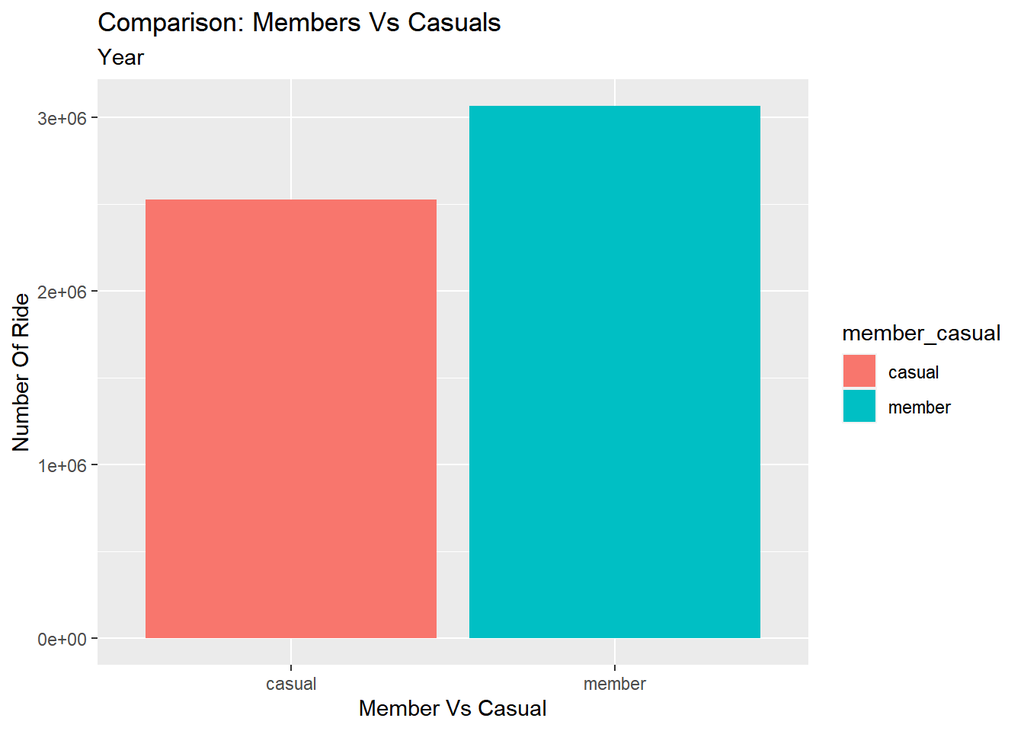

```r
ggplot(annual_tripdata_cleaned)+
  geom_bar(mapping = aes(x = member_casual, fill = member_casual))+
  labs(title = "Comparison: Members Vs Casuals", subtitle = "Year", x = "Member Vs Casual", y = "Number Of Ride")
```

casual 2528664 45.19983 = ~45%  
member 3065746 54.80017 = ~55%

Based on the calculation during my analysis phase members ride ~10% more than casuals.

Comparison on Number of rides based on monthly ride

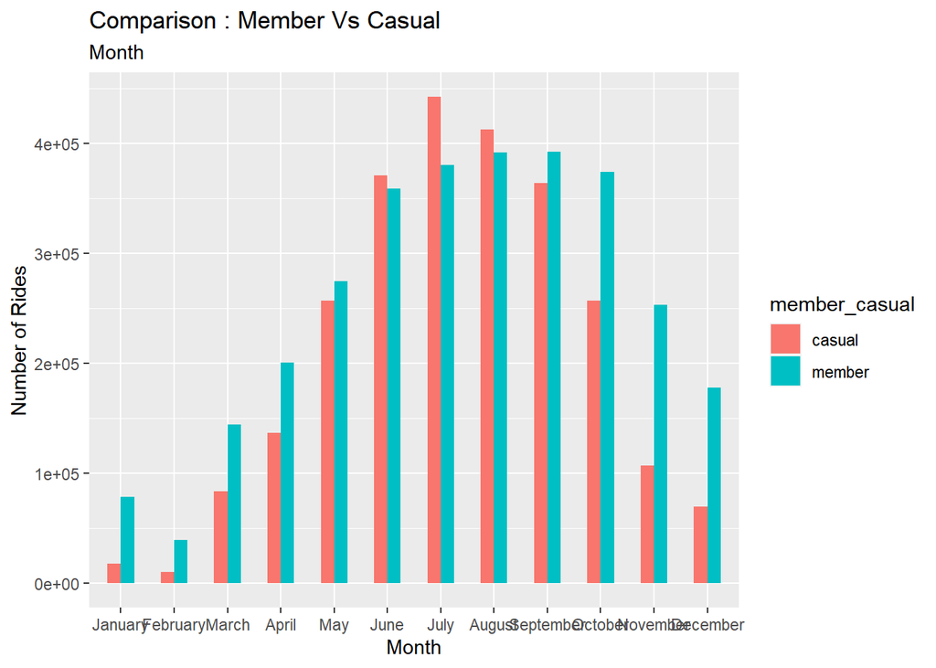

```r
ggplot()+
  geom_bar(annual_tripdata_cleaned, mapping = aes(x = month, fill = member_casual), position = "dodge", width = 0.5)+
  labs(title = "Comparison : Member Vs Casual", subtitle = "Month", x = "Month", y = "Number of Rides")
```

The first five months and the last four months members ride more than casuals, on the other hand during summer time (June, July and August) casuals ride more than members.

Comparison on number of rides based on the day of week

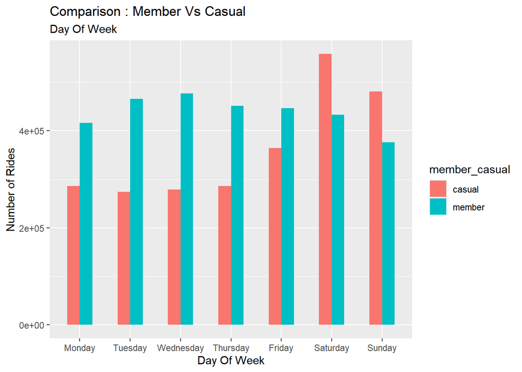

```r
ggplot()+
  geom_bar(annual_tripdata_cleaned, mapping = aes(x = day_of_week, fill = member_casual), position = "dodge", width = 0.5)+
  labs(title = "Comparison : Member Vs Casual", subtitle = "Day Of Week", x = "Day Of Week", y = "Number of Rides")
```

Members ride more than casuals during week day, while casuals ride more than members during the week end.

Comparison on rideable type between Member and Casual

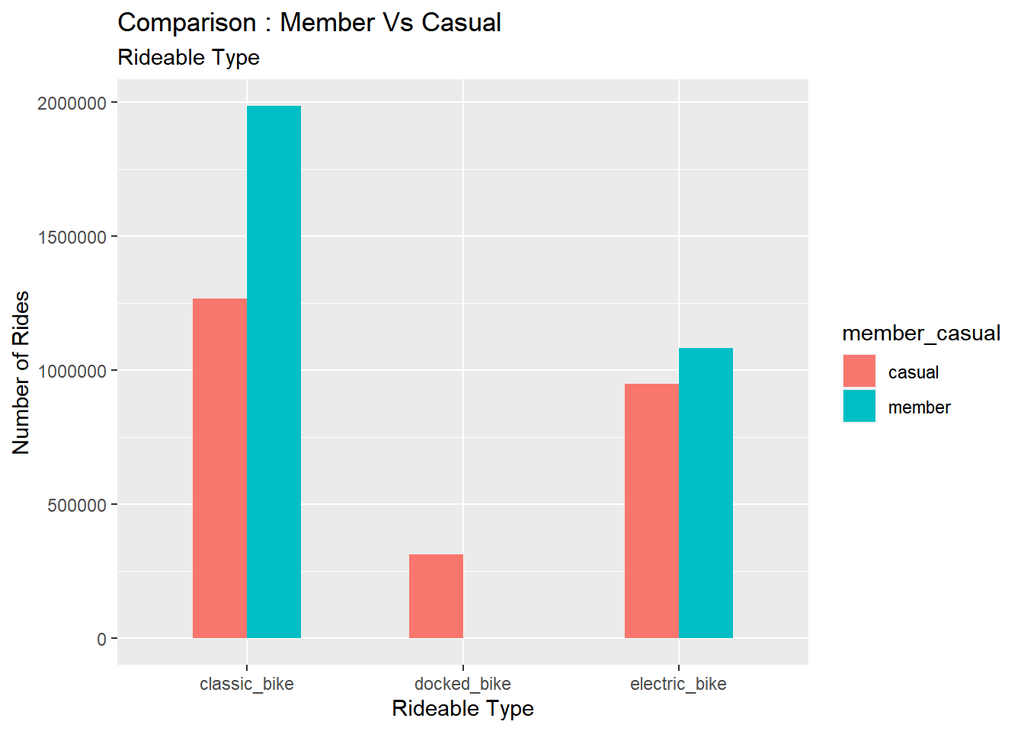

```r
ggplot()+
  geom_bar(annual_tripdata_cleaned, mapping = aes(x = rideable_type, fill = member_casual), position = "dodge", width = 0.5)+
  labs(title = "Comparison : Member Vs Casual", subtitle = "Rideable Type", x = "Rideable Type", y = "Number of Rides")
```

Members use more classic and electric bike than casuals, while casuals use more docked bike than members.

## My recommendations

1 - Create an annual month promotions for new members specially for casual riders

2 - Create seasonal promotions for new members like weekly promotions

3- Have visual or physical marketing promotions during the week end and summer time on each station so it will draw the attention of casual riders.